# **Fan Impact at Home in the 2023 NFL Season**

Zoe Murphy and Allison Wu

Link to Website: https://awu3t.github.io/

Link to Data Set One: https://www.pro-football-reference.com/years/2023/games.htm

Link to Data Set Two: https://www.pro-football-reference.com/years/2023/attendance.htm

Data Set Three: https://drive.google.com/file/d/1Vpr6ABqOK3EKoP3MdMdth_1YVvbRNICM/view?usp=drive_link

Data Set Four: https://www.pro-football-reference.com/years/2022/attendance.htm

## **Project Plan**

This will be an investigation into NFL data from 2023. We will be looking at home wins, home team attendance, figure out what percent of each NFL stadium was filled, and use that data to learn about fan impacts at home stadiums. This will allow us to determine if there is a certain stadium that has an advantage to play at because of the fans.

Questions we wil look at include 'How impactful is the home-field advtantage because of the fans?' 'Is fan attendance a measurable factor for team success?' and other questions that may come up while looking into the data sets.

## **Collaboration Plan**

Our team will be meeting together once a week in person. During these meetings, we will look for datasets, discuss what information to use from tables, create visualizations, and make predictions for the project. Additionally, we will communicate via text messages in case any issues come up when we are working on individually outside of our meeting.

## **Data Set One: Each NFL Football Game for 2023**

This data set comes from Pro-Football-Reference.com. This site collects data from each NFL season and makes tables out of it for people to use. With this table, the unit of observation is an NFL game from the 2023 season. This data set shows each game starting from week 1 all the way to the SuperBowl. It specifies the winner, loser, when the game was, and specifics with the points and yards. Through some data transformations, we can find out how often home teams won. Combining this table with other data sets could bring interesting information, especially with seeing what can influence a home team advantage.

For anyone who is unfamiliar with the NFL schedule, this is a great source to look at: https://operations.nfl.com/gameday/nfl-schedule/creating-the-nfl-schedule/ . It provides great detail into all of the different factors and decisions that are made to create the NFL schedule for each season.

```python
schedule_data = pd.read_html("https://www.pro-football-reference.com/years/2023/games.htm#games") # Reads entire table in as a list
schedule_data = schedule_data[0] # Takes the first part of list (so the entire table)
schedule_data
```

|  | Week | Day | Date | Time | Winner/tie | Unnamed: 5 | Loser/tie | Unnamed: 7 | PtsW | PtsL | YdsW | TOW | YdsL | TOL |
| --- | --- | --- | --- | --- | --- | --- | --- | --- | --- | --- | --- | --- | --- | --- |
| 0 | 1 | Thu | 2023-09-07 | 8:20PM | Detroit Lions | @ | Kansas City Chiefs | boxscore | 21 | 20 | 368 | 1 | 316 | 1 |
| 1 | 1 | Sun | 2023-09-10 | 1:00PM | Atlanta Falcons | NaN | Carolina Panthers | boxscore | 24 | 10 | 221 | 0 | 281 | 3 |
| 2 | 1 | Sun | 2023-09-10 | 1:00PM | Cleveland Browns | NaN | Cincinnati Bengals | boxscore | 24 | 3 | 350 | 2 | 142 | 0 |
| 3 | 1 | Sun | 2023-09-10 | 1:00PM | Jacksonville Jaguars | @ | Indianapolis Colts | boxscore | 31 | 21 | 342 | 2 | 280 | 3 |
| 4 | 1 | Sun | 2023-09-10 | 1:00PM | Washington Commanders | NaN | Arizona Cardinals | boxscore | 20 | 16 | 248 | 3 | 210 | 2 |
| ... | ... | ... | ... | ... | ... | ... | ... | ... | ... | ... | ... | ... | ... | ... |
| 298 | Division | Sun | 2024-01-21 | 3:00PM | Detroit Lions | NaN | Tampa Bay Buccaneers | boxscore | 31 | 23 | 391 | 0 | 408 | 2 |
| 299 | Division | Sun | 2024-01-21 | 6:30PM | Kansas City Chiefs | @ | Buffalo Bills | boxscore | 27 | 24 | 361 | 1 | 368 | 0 |
| 300 | ConfChamp | Sun | 2024-01-28 | 3:00PM | Kansas City Chiefs | @ | Baltimore Ravens | boxscore | 17 | 10 | 319 | 0 | 336 | 3 |
| 301 | ConfChamp | Sun | 2024-01-28 | 6:30PM | San Francisco 49ers | NaN | Detroit Lions | boxscore | 34 | 31 | 413 | 1 | 442 | 1 |
| 302 | SuperBowl | Sun | 2024-02-11 | 6:30PM | Kansas City Chiefs | N | San Francisco 49ers | boxscore | 25 | 22 | 455 | 2 | 382 | 2 |

303 rows × 14 columns

We really only want the columns with the game week, winner, loser, and if it was a home or away game. So, we can just drop those extra columns.

The column titled "Unnamed: 5" shows if it that respective game was a home or away game. We need to rename it so that that's more clear. Additionally, the data in that column is either "@" or NaN, but we want to change them to "Away" or "Home."

```python
# Changes to Columns and their Values

schedule_data.drop(["Day", "Date", "Time", "Unnamed: 7", "PtsW", "PtsL", "YdsW", "TOW", "YdsL", "TOL"], axis=1, inplace=True)
schedule_data.rename(columns={"Unnamed: 5": "Winner: Home or Away Game"}, inplace=True)
schedule_data["Winner: Home or Away Game"] = schedule_data["Winner: Home or Away Game"].map({"@": "Away"}).fillna("Home")
```

We also want to get rid of certain values, like playoff games. Playoff games could be considered outliers, as they're very different than regular season games. Both teams have a lot more on the line! Since this list goes in order, we can just remove the last rows related to playoffs.

Also, every 17 rows, there's a blank row with NaN values and the team is listed as "Winner/tie." We want to remove those rows so that they don't affect any of our calculations.

```python
# Deleting Specified Rows

schedule_data.dropna(subset=["Winner/tie"], inplace=True) # Drop rows with NaN
rows_without_team = schedule_data[schedule_data["Winner/tie"].str.contains("Winner/tie")].index # Specifies rows with "Winner/tie" should be dropped
schedule_data.drop(rows_without_team, axis=0, inplace=True) # Drop those rows
schedule_data.drop(schedule_data.index[-14:], axis=0, inplace=True) # Drop Playoff Games
schedule_data
```

|  | Week | Winner/tie | Winner: Home or Away Game | Loser/tie |
| --- | --- | --- | --- | --- |
| 0 | 1 | Detroit Lions | Away | Kansas City Chiefs |
| 1 | 1 | Atlanta Falcons | Home | Carolina Panthers |
| 2 | 1 | Cleveland Browns | Home | Cincinnati Bengals |
| 3 | 1 | Jacksonville Jaguars | Away | Indianapolis Colts |
| 4 | 1 | Washington Commanders | Home | Arizona Cardinals |
| ... | ... | ... | ... | ... |
| 283 | 18 | Dallas Cowboys | Away | Washington Commanders |
| 284 | 18 | Las Vegas Raiders | Home | Denver Broncos |
| 285 | 18 | Kansas City Chiefs | Away | Los Angeles Chargers |
| 286 | 18 | New York Giants | Home | Philadelphia Eagles |
| 287 | 18 | Los Angeles Rams | Away | San Francisco 49ers |

271 rows × 4 columns

Now, we should make sure our values are being interpreted correctly.

```python
schedule_data.dtypes
```

|  | 0 |
| --- | --- |
| Week | object |
| Winner/tie | object |
| Winner: Home or Away Game | object |
| Loser/tie | object |

**dtype:** object

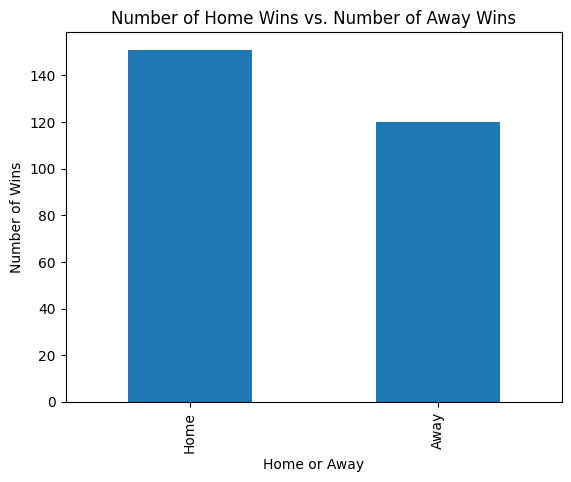

```python
home_away_count = schedule_data["Winner: Home or Away Game"].value_counts() # Gets the count of home/away wins
home_away_count.plot.bar(xlabel="Home or Away", ylabel="Number of Wins", title= "Number of Home Wins vs. Number of Away Wins") # Plots the count
```

Now, we want a column that will tell us exactly who the home team was instead of having to read three different columns to figure out who was at home. We will create a new column called "Home Team" and use if/else logic. We want to determine the home team for each row/unit of observation. Therefore, we will check the column "Winner: Home or Away Game," row by row. If the value is "Away," then we will put the value from the "Loser/tie" column into the new column. If the value is "Home," then we will put the value from the "Winner/tie" column into the new column. It will do this for every single row. This data wil come in handy when we're combining the table with other data sets.

```python
# Create new column and apply the if/else logic to each value
schedule_data["Home Team"] = schedule_data.apply(
    lambda row: row["Loser/tie"] if row["Winner: Home or Away Game"] == "Away" else row["Winner/tie"], axis=1
)

schedule_data
```

|  | Week | Winner/tie | Winner: Home or Away Game | Loser/tie | Home Team |
| --- | --- | --- | --- | --- | --- |
| 0 | 1 | Detroit Lions | Away | Kansas City Chiefs | Kansas City Chiefs |
| 1 | 1 | Atlanta Falcons | Home | Carolina Panthers | Atlanta Falcons |
| 2 | 1 | Cleveland Browns | Home | Cincinnati Bengals | Cleveland Browns |
| 3 | 1 | Jacksonville Jaguars | Away | Indianapolis Colts | Indianapolis Colts |
| 4 | 1 | Washington Commanders | Home | Arizona Cardinals | Washington Commanders |
| ... | ... | ... | ... | ... | ... |
| 283 | 18 | Dallas Cowboys | Away | Washington Commanders | Washington Commanders |
| 284 | 18 | Las Vegas Raiders | Home | Denver Broncos | Las Vegas Raiders |
| 285 | 18 | Kansas City Chiefs | Away | Los Angeles Chargers | Los Angeles Chargers |
| 286 | 18 | New York Giants | Home | Philadelphia Eagles | New York Giants |
| 287 | 18 | Los Angeles Rams | Away | San Francisco 49ers | San Francisco 49ers |

271 rows × 5 columns

This table below will show us the number of home wins for each team. Similarly to the previous function, we can use if/else logic to extract important information. We will create a new column called "Home Wins." The if/else logic is checking if the "Winner/tie" column is equal to the "Home Team" column for every row. If they are equal, "Home Wins" is 1, and if not, then it'll be 0.

Then, we can group the data by the "Winner/tie" column and sum up the home wins for each team.

The data is showing that the Cleveland Browns and the Cowboys seem to have the most home wins in the 2023 season. It will be useful to look at this in comparison to the attendance numbers with the other teams to see if the fans might have had an impact on their performance. Do AT&T Stadium (Cowboys) and Huntington Bank Field (Browns) provide an automatic advantage?

```python
# Create new column and apply if/else logic
schedule_data["Home Wins"] =schedule_data.apply(
    lambda row: 1 if row["Winner/tie"] == row["Home Team"] else 0, axis=1
)

# New df grouped by winning team. Sums up the teams home wins
Grouped_home_team_wins = schedule_data.groupby("Winner/tie")["Home Wins"].sum()

# Sorts from most home wins to least
Grouped_home_team_wins.sort_values(ascending=False)
```

| Winner/tie | Home Wins |
| --- | --- |
| Cleveland Browns | 8 |
| Dallas Cowboys | 8 |
| Miami Dolphins | 7 |
| Buffalo Bills | 7 |
| Las Vegas Raiders | 6 |
| Houston Texans | 6 |
| Detroit Lions | 6 |
| Philadelphia Eagles | 6 |
| Cincinnati Bengals | 6 |
| Baltimore Ravens | 6 |
| Chicago Bears | 5 |
| Green Bay Packers | 5 |
| Tennessee Titans | 5 |
| Pittsburgh Steelers | 5 |
| Kansas City Chiefs | 5 |
| Atlanta Falcons | 5 |
| Denver Broncos | 5 |
| Los Angeles Rams | 5 |
| Seattle Seahawks | 5 |
| San Francisco 49ers | 5 |
| New Orleans Saints | 5 |
| New York Giants | 4 |
| New York Jets | 4 |
| Tampa Bay Buccaneers | 4 |
| Jacksonville Jaguars | 4 |
| Indianapolis Colts | 4 |
| Arizona Cardinals | 2 |
| Minnesota Vikings | 2 |
| Los Angeles Chargers | 2 |
| Carolina Panthers | 2 |
| New England Patriots | 1 |
| Washington Commanders | 1 |

**dtype:** int64

## **Data Set Two: NFL Team Attendance by Week**

This data set, also from Pro-Football-Reference.com, goes over each teams attendance by week. We can see which teams had the greatest total home attendance. This does not include playoff games, it is only the regular season.

This set does not specify if they had a home or away game week by week, so we can use the data from the first set to connect that together. By doing that, we can figure out the home attendance for each game.

It will be useful to connect this data with the capacity of each NFL stadium. Then, we can see the percentage of how full each NFL stadium was.

```python
attendance_data = pd.read_html("https://www.pro-football-reference.com/years/2023/attendance.htm#attendance") # Reads entire table in as a list
attendance_data = attendance_data[0] # Takes the first part of list (so the entire table)
```

We don't need the last row which is a mix of NaN values and totals for the week.

```python
attendance_data.drop(attendance_data.index[-1], axis=0, inplace=True)
attendance_data=attendance_data[["Tm","Home"]]
attendance_data
```

|  | Tm | Home |
| --- | --- | --- |
| 0 | Arizona Cardinals | 502912.0 |
| 1 | Atlanta Falcons | 556828.0 |
| 2 | Baltimore Ravens | 635380.0 |
| 3 | Buffalo Bills | 626483.0 |
| 4 | Carolina Panthers | 573086.0 |
| 5 | Chicago Bears | 494157.0 |
| 6 | Cincinnati Bengals | 594361.0 |
| 7 | Cleveland Browns | 610295.0 |
| 8 | Dallas Cowboys | 748755.0 |
| 9 | Denver Broncos | 687498.0 |
| 10 | Detroit Lions | 518741.0 |
| 11 | Green Bay Packers | 622636.0 |
| 12 | Houston Texans | 640742.0 |
| 13 | Indianapolis Colts | 587393.0 |
| 14 | Jacksonville Jaguars | 621599.0 |
| 15 | Kansas City Chiefs | 638715.0 |
| 16 | Las Vegas Raiders | 559713.0 |
| 17 | Los Angeles Chargers | 627632.0 |
| 18 | Los Angeles Rams | 585204.0 |
| 19 | Miami Dolphins | 593304.0 |
| 20 | Minnesota Vikings | 535308.0 |
| 21 | New England Patriots | 567168.0 |
| 22 | New Orleans Saints | 560164.0 |
| 23 | New York Giants | 634459.0 |
| 24 | New York Jets | 701011.0 |
| 25 | Philadelphia Eagles | 559032.0 |
| 26 | Pittsburgh Steelers | 602796.0 |
| 27 | San Francisco 49ers | 573245.0 |
| 28 | Seattle Seahawks | 549886.0 |
| 29 | Tampa Bay Buccaneers | 510321.0 |
| 30 | Tennessee Titans | 580686.0 |
| 31 | Washington Commanders | 511606.0 |

```python
attendance_data.dtypes
```

|  | 0 |
| --- | --- |
| Tm | object |
| Home | float64 |

**dtype:** object

The mean and median home attendance for the teams were pretty close to each other. There shouldn't be a huge outlier in this data!

```python
attendance_data["Home"].mean()
```

```
590972.375
```

```python
attendance_data["Home"].median()
```

```
586298.5
```

Let's just look at the overall home attendance numbers. Again, these will be more useful with analysis into the stadium size.

We notice that the Dallas Cowboys had the highest overall home attendance. With the Cowboys having the most home wins and the most fans at their home games, it could be a sign that they have the best home field advantage. However, the Cleveland Browns were 12th on the list, but tied for first for home wins. This shows that we need some more analysis before we make conclusions.

```python
# Create df grouped by the team and showing the total home attendance
total_home_attendance = attendance_data.groupby("Tm")["Home"].sum()

# Sort them from highest to lowest
total_home_attendance.sort_values(ascending=False)
```

| Tm | Home |
| --- | --- |
| Dallas Cowboys | 748755.0 |
| New York Jets | 701011.0 |
| Denver Broncos | 687498.0 |
| Houston Texans | 640742.0 |
| Kansas City Chiefs | 638715.0 |
| Baltimore Ravens | 635380.0 |
| New York Giants | 634459.0 |
| Los Angeles Chargers | 627632.0 |
| Buffalo Bills | 626483.0 |
| Green Bay Packers | 622636.0 |
| Jacksonville Jaguars | 621599.0 |
| Cleveland Browns | 610295.0 |
| Pittsburgh Steelers | 602796.0 |
| Cincinnati Bengals | 594361.0 |
| Miami Dolphins | 593304.0 |
| Indianapolis Colts | 587393.0 |
| Los Angeles Rams | 585204.0 |
| Tennessee Titans | 580686.0 |
| San Francisco 49ers | 573245.0 |
| Carolina Panthers | 573086.0 |
| New England Patriots | 567168.0 |
| New Orleans Saints | 560164.0 |
| Las Vegas Raiders | 559713.0 |
| Philadelphia Eagles | 559032.0 |
| Atlanta Falcons | 556828.0 |
| Seattle Seahawks | 549886.0 |
| Minnesota Vikings | 535308.0 |
| Detroit Lions | 518741.0 |
| Washington Commanders | 511606.0 |
| Tampa Bay Buccaneers | 510321.0 |
| Arizona Cardinals | 502912.0 |
| Chicago Bears | 494157.0 |

**dtype:** float64

## **Data Set Three: Stadium Capacity**

This data set gives lots of different statistics and data points about each NFL stadium. What we're most interested in is each stadium's capacity. We can divide the weekly attendance by the stadium capacity to see what percent of the stadium was actually filled with fans. This is more reliable than just attendance alone since stadiums can vary greatly in size.

```python
stadium_data = pd.read_csv('/content/drive/MyDrive/NFL_Stadium.csv')
stadium_data
```

|  | Name | Team(s) | Capacity | Opened | Turf | Cost |
| --- | --- | --- | --- | --- | --- | --- |
| 0 | Acrisure Stadium | Pittsburgh Steelers | 68,400 | 10/07/2001 | Grass | $281 Million |
| 1 | Allegiant Stadium | Las Vegas Raiders | 65,000 | NaN | Grass | $1.9 Billion |
| 2 | Arrowhead Stadium | Kansas City Chiefs | 76,416 | 08/12/1972 | Grass | $43 Million |
| 3 | AT&T Stadium | Dallas Cowboys | 80,000 | NaN | FieldTurf | $1.3 Billion |
| 4 | Bank of America Stadium | Carolina Panthers | 74,867 | NaN | Grass | $242 Million |
| 5 | Caesars Superdome | New Orleans Saints | 73,208 | NaN | FieldTurf | $134 Million |
| 6 | Empower Field | Denver Broncos | 76,125 | 09/10/2001 | Grass | $364 Million |
| 7 | EverBank Field | Jacksonville Jaguars | 67,264 | NaN | Grass | $134 Million |
| 8 | Ford Field | Detroit Lions | 65,000 | NaN | FieldTurf | $430 Million |
| 9 | Gillette Stadium | New England Patriots | 65,878 | 09/09/2002 | Fieldturf | $325 Million |
| 10 | Hard Rock Stadium | Miami Dolphins | 65,326 | NaN | Grass | $115 Million |
| 11 | Highmark Stadium | Buffalo Bills | 71,608 | NaN | FieldTurf | $22 Million |
| 12 | Huntington Bank Field | Cleveland Browns | 67,895 | 09/12/1999 | Grass | $290 Million |
| 13 | Lambeau Field | Green Bay Packers | 81,441 | NaN | Grass | $ 960,000 |
| 14 | Levi’s Stadium | San Francisco 49ers | 68,500 | NaN | Grass | $1.3 Billion |
| 15 | Lincoln Financial Field | Philadelphia Eagles | 67,594 | 09/08/2003 | Grass | $518 Million |
| 16 | Lucas Oil Stadium | Indianapolis Colts | 67,000 | 09/07/2008 | Fieldturf | $720 Million |
| 17 | Lumen Field | Seattle Seahawks | 68,740 | NaN | FieldTurf | $360 Million |
| 18 | M&T Bank Stadium | Baltimore Ravens | 71,008 | 09/06/1998 | Fieldturf | $220 Million |
| 19 | Mercedes Benz Stadium | Atlanta Falcons | 71,000 | NaN | Fieldturf | $1.5 Billion |
| 20 | MetLife Stadium | New York Giants/Jets | 82,500 | 09/12/2010 | FieldTurf | $1.6 Billion |
| 21 | Nissan Stadium | Tennessee Titans | 69,143 | 09/12/1999 | Grass | $290 Million |
| 22 | Northwest Stadium | Washington Commanders | 79,000 | NaN | Grass | $250 Million |
| 23 | NRG Stadium | Houston Texans | 71,795 | 09/08/2002 | Grass | $449 Million |
| 24 | Paycor Stadium | Cincinnati Bengals | 65,515 | 09/10/2000 | Fieldturf | $450 Million |
| 25 | Raymond James Stadium | Tampa Bay Buccaneers | 65,890 | NaN | Grass | $194 Million |
| 26 | SoFi Stadium | Los Angeles Rams/Chargers | 70,000 | NaN | FieldTurf | $4.9 Billion |
| 27 | Soldier Field | Chicago Bears | 61,500 | NaN | Grass | $600 Million |
| 28 | University of Phoenix Stadium | Arizona Cardinals | 63,400 | 09/10/2006 | Grass | $455 Million |
| 29 | US Bank Stadium | Minnesota Vikings | 66,200 | NaN | Fieldturf | $1.1 Billion |

We see that there are a lot of values we don't need since we're just looking at the stadium capacity for each team. We can drop a lot of these columns.

```python
stadium_data.drop(["Name", "Opened", "Turf", "Cost"], axis=1, inplace=True)
```

The table looks a lot better now, but there's still a small issue. The New York Giants and New York Jets share a stadium. The Los Angeles Rams and Los Angeles Chargers also share a stadium. We need each team to have its own row, so we're going to manually add in some rows and rename current rows.

```python
# Renaming the Team column name for the Rams/Chargers
stadium_data.loc[stadium_data["Team(s)"] == "Los Angeles Rams/Chargers", "Team(s)"] = "Los Angeles Rams"

# Creating a row variable for the LA Chargers
chargers = pd.DataFrame({"Team(s)": "Los Angeles Chargers", "Capacity": ["70,000"] })

# Renaming the Team column name for the Giants/Jets
stadium_data.loc[stadium_data["Team(s)"] == "New York Giants/Jets", "Team(s)"] = "New York Giants"

# Creating a row variable for the NY Jets
jets = pd.DataFrame({"Team(s)": "New York Jets", "Capacity": ["82,500"]})

# Adding the new rows into the stadium_data dataframe
stadium_data = pd.concat([stadium_data, chargers, jets], ignore_index=True)
```

Now, let's double check the data types before we start organizing data and merging tables

```python
stadium_data.dtypes
```

|  | 0 |
| --- | --- |
| Team(s) | object |
| Capacity | object |

**dtype:** object

There's one last issue before we start working with the data. When we look at the datatypes, the capacity is showing up as a variable. We need it to be of type "int." To fix this, we are going to replace the commas in the numerical values and assign them to type int.

```python
# This basically deletes each comma and replaces it with nothing
stadium_data["Capacity"] = stadium_data["Capacity"].str.replace(",", "")

# Converts everything in the "Capacity" column to an integer
stadium_data["Capacity"] = stadium_data["Capacity"].astype(int)
```

Now that everything is set in place, let's sort the data to see which stadium is the biggest.

```python
stadium_data.sort_values(by="Capacity", ascending=False, inplace=True)
stadium_data.rename(columns={"Team(s)": "Team"}, inplace=True)
# stadium_data["Team"]=stadium_data["Team(s)"]

stadium_data
```

|  | Team | Capacity |
| --- | --- | --- |
| 31 | New York Jets | 82500 |
| 20 | New York Giants | 82500 |
| 13 | Green Bay Packers | 81441 |
| 3 | Dallas Cowboys | 80000 |
| 22 | Washington Commanders | 79000 |
| 2 | Kansas City Chiefs | 76416 |
| 6 | Denver Broncos | 76125 |
| 4 | Carolina Panthers | 74867 |
| 5 | New Orleans Saints | 73208 |
| 23 | Houston Texans | 71795 |
| 11 | Buffalo Bills | 71608 |
| 18 | Baltimore Ravens | 71008 |
| 19 | Atlanta Falcons | 71000 |
| 26 | Los Angeles Rams | 70000 |
| 30 | Los Angeles Chargers | 70000 |
| 21 | Tennessee Titans | 69143 |
| 17 | Seattle Seahawks | 68740 |
| 14 | San Francisco 49ers | 68500 |
| 0 | Pittsburgh Steelers | 68400 |
| 12 | Cleveland Browns | 67895 |
| 15 | Philadelphia Eagles | 67594 |
| 7 | Jacksonville Jaguars | 67264 |
| 16 | Indianapolis Colts | 67000 |
| 29 | Minnesota Vikings | 66200 |
| 25 | Tampa Bay Buccaneers | 65890 |
| 9 | New England Patriots | 65878 |
| 24 | Cincinnati Bengals | 65515 |
| 10 | Miami Dolphins | 65326 |
| 1 | Las Vegas Raiders | 65000 |
| 8 | Detroit Lions | 65000 |
| 28 | Arizona Cardinals | 63400 |
| 27 | Chicago Bears | 61500 |

## **Combining Tables**

To make a claim about home base attendance and its ability to affect the performance of the players, we need to find the percentage capacity of the stadium that is filled. To achieve this, we are creating a new table with the teams, their home base stadiums, the capacity of those stadiums, and the attendance at the game. Then, we will calculate the attendance percentage by dividing the attendance by the total capacity of the stadium. Then, we will create some graphs to look at trends/correlations with the records of each team.

```python
# Creates new dataframe, sorted alphabetically by team
teams_capacity = stadium_data.sort_values('Team') # axis=0 is default for sorting by rows/index
teams_capacity.reset_index(drop=True, inplace=True)
```

```python
# Merges the stadium data in teams capacity with the total home attendance from attendance_data
teams_capacity = teams_capacity.merge(attendance_data, left_on="Team",
                                    right_on="Tm")[['Team', 'Capacity', 'Home']]
```

```python
afc=['Baltimore Ravens', 'Buffalo Bills','Cincinnati Bengals', 'Cleveland Browns',
    "Denver Broncos", 'Pittsburgh Steelers', 'Houston Texans', 'Indianapolis Colts',
     'Jacksonville Jaguars', 'Tennessee Titans', 'Miami Dolphins',
     'New England Patriots', 'New York Jets', 'Kansas City Chiefs'
     'Las Vegas Raiders', 'Los Angeles Chargers']

# If statement to divde the overall home attendance by 9 if an afc team or 8 if it's not an afc team
teams_capacity['Average Home Attendance'] = teams_capacity.apply(lambda row:
  row['Home'] / 9 if row['Team'] in afc else row['Home'] / 8, axis=1)
```

To see the overall attendance percentage, we need to average the home attendance and divide it by the stadium capacity. Then, we can multiply it by 100 to get a percentage.

```python
teams_capacity["Attendance Percentage"] = (teams_capacity["Average Home Attendance"]
                                           / teams_capacity["Capacity"] * 100)
```

```python
# Drop columns that we don't need anymore
teams_capacity.drop(columns=["Average Home Attendance", "Capacity", "Home"], inplace=True)
```

```python
# Add the home wins to the table so we can see the trends and compare
home_wins = Grouped_home_team_wins.sort_values()

teams_capacity=teams_capacity.merge(home_wins, left_on="Team",
                                    right_on="Winner/tie")

teams_capacity.sort_values(by="Home Wins", inplace=True, ascending=False)
teams_capacity.reset_index(drop=True, inplace=True)

teams_capacity
```

|  | Team | Attendance Percentage | Home Wins |
| --- | --- | --- | --- |
| 0 | Cleveland Browns | 99.875625 | 8 |
| 1 | Dallas Cowboys | 116.992969 | 8 |
| 2 | Miami Dolphins | 100.913368 | 7 |
| 3 | Buffalo Bills | 97.208723 | 7 |
| 4 | Las Vegas Raiders | 107.637115 | 6 |
| 5 | Houston Texans | 99.162275 | 6 |
| 6 | Detroit Lions | 99.757885 | 6 |
| 7 | Philadelphia Eagles | 103.380478 | 6 |
| 8 | Cincinnati Bengals | 100.801513 | 6 |
| 9 | Baltimore Ravens | 99.422287 | 6 |
| 10 | Chicago Bears | 100.438415 | 5 |
| 11 | Green Bay Packers | 95.565501 | 5 |
| 12 | Tennessee Titans | 93.314821 | 5 |
| 13 | Pittsburgh Steelers | 97.920078 | 5 |
| 14 | Kansas City Chiefs | 104.479919 | 5 |
| 15 | Atlanta Falcons | 98.033099 | 5 |
| 16 | Denver Broncos | 100.346360 | 5 |
| 17 | Los Angeles Rams | 104.500714 | 5 |
| 18 | Seattle Seahawks | 99.993817 | 5 |
| 19 | San Francisco 49ers | 104.606752 | 5 |
| 20 | New Orleans Saints | 95.645968 | 5 |
| 21 | New York Giants | 96.130152 | 4 |
| 22 | New York Jets | 94.412256 | 4 |
| 23 | Tampa Bay Buccaneers | 96.813060 | 4 |
| 24 | Jacksonville Jaguars | 102.679822 | 4 |
| 25 | Indianapolis Colts | 97.411774 | 4 |
| 26 | Arizona Cardinals | 99.154574 | 2 |
| 27 | Minnesota Vikings | 101.077795 | 2 |
| 28 | Los Angeles Chargers | 99.624127 | 2 |
| 29 | Carolina Panthers | 95.684013 | 2 |
| 30 | New England Patriots | 95.659654 | 1 |
| 31 | Washington Commanders | 80.950316 | 1 |

You may notice in the table above that some teams have over 100% of their capacity. This can happen because the stadium capacity value is only counting actual physical seats. Oftentimes, teams will sell standing room only tickets. These will cause the stadium to have more fans than they have seats.

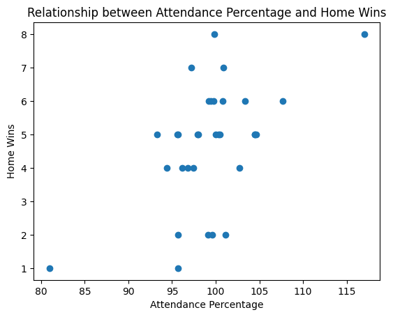

```python
import matplotlib.pyplot as plt

plt.scatter(teams_capacity["Attendance Percentage"], teams_capacity["Home Wins"])
plt.xlabel("Attendance Percentage")
plt.ylabel("Home Wins")
plt.title("Relationship between Attendance Percentage and Home Wins")
plt.show()
```

## **Preprocessing For Our Model**

We are going to build a model that helps us see how strong of a relationship there is between the attendance percentage and the number of home wins. Hopefully, the model can accurately predict the correct number of home wins for each team. We are going to need some more data to make predictions, so we will read in the same data above, but for the 2022 season.

To work with the 2022 data, we are going to read in the same exact files at the start of the lab, just the 2022 versions. In the code box below, we ran the same exact commands that we did for Data Set 1.

```python
schedule_data2022 = pd.read_html("https://www.pro-football-reference.com/years/2022/games.htm") # Reads entire table in as a list
schedule_data2022 = schedule_data2022[0] # Takes the first part of list (so the entire table)

# Drops unnecessary columns, renames certain columns, and maps new values in the columns
schedule_data2022.drop(["Day", "Date", "Time", "Unnamed: 7", "PtsW", "PtsL", "YdsW", "TOW", "YdsL", "TOL"], axis=1, inplace=True)
schedule_data2022.rename(columns={"Unnamed: 5": "Winner: Home or Away Game"}, inplace=True)
schedule_data2022["Winner: Home or Away Game"] = schedule_data2022["Winner: Home or Away Game"].map({"@": "Away"}).fillna("Home")

# Deleting Specified Rows
schedule_data2022.dropna(subset=["Winner/tie"], inplace=True) # Drop rows with NaN
rows_without_team = schedule_data2022[schedule_data2022["Winner/tie"].str.contains("Winner/tie")].index # Specifies rows with "Winner/tie" should be dropped
schedule_data2022.drop(rows_without_team, axis=0, inplace=True) # Drop those rows
schedule_data2022.drop(schedule_data2022.index[-14:], axis=0, inplace=True) # Drop Playoff Games

# If statement to determine if the home team lost or won
schedule_data2022["Home Team"] = schedule_data2022.apply(
    lambda row: row["Loser/tie"] if row["Winner: Home or Away Game"] == "Away" else row["Winner/tie"], axis=1
)
# Create new column and apply if/else logic
schedule_data2022["Home Wins"] =schedule_data2022.apply(
    lambda row: 1 if row["Winner/tie"] == row["Home Team"] else 0, axis=1
)
# Groups the number of home wins by team
Grouped_home_team_wins2022 = schedule_data2022.groupby("Winner/tie")["Home Wins"].sum()
```

This code block below does the same exact commands and data processing for what we did in Data Set Two, but for the 2022 attendance data.

```python
attendance_data2022 = pd.read_html("https://www.pro-football-reference.com/years/2022/attendance.htm") # Reads entire table in as a list
attendance_data2022 = attendance_data2022[0] # Takes the first part of list (so the entire table)

# Drops specified row and makes the dataframe only the team and home attendance
attendance_data2022.drop(attendance_data2022.index[-1], axis=0, inplace=True)
attendance_data2022 = attendance_data2022[["Tm","Home"]]
```

The code block below combines the tables we loaded in for 2022 and the stadium data (Data Set Three). Again, it's the same exact code that we used in the section above. The only thing we had to change was what we were dividing by to get the average home attendance for each game. For 2022, the AFC teams had 8 home games instead of 9 and the NFC had 9 home games instead of 8.

```python
# Creates new dataframe, sorted alphabetically by team
teams_capacity2022 = stadium_data.sort_values('Team') # axis=0 is default for sorting by rows/index
teams_capacity2022.reset_index(drop=True, inplace=True)

# Merges the stadium data in teams capacity with the total home attendance from attendance_data2022
teams_capacity2022 = teams_capacity2022.merge(attendance_data2022, left_on="Team",
                                    right_on="Tm")[['Team', 'Capacity', 'Home']]

# If statement to divde the overall home attendance by 8 if an afc team or 9 if it's not an afc team
teams_capacity2022['Average Home Attendance'] = teams_capacity2022.apply(lambda row:
  row['Home'] / 8 if row['Team'] in afc else row['Home'] / 9, axis=1)

teams_capacity2022["Attendance Percentage"] = (teams_capacity2022["Average Home Attendance"]
                                           / teams_capacity2022["Capacity"] * 100)

# Drop columns that we don't need anymore
teams_capacity2022.drop(columns=["Average Home Attendance", "Capacity", "Home"], inplace=True)

# Add the home wins to the table so we can see the trends and compare
home_wins2022 = Grouped_home_team_wins2022.sort_values()
teams_capacity2022=teams_capacity2022.merge(home_wins2022, left_on="Team",
                                    right_on="Winner/tie")
teams_capacity2022.sort_values(by="Home Wins", inplace=True, ascending=False)
teams_capacity2022.reset_index(drop=True, inplace=True)

teams_capacity2022
```

|  | Team | Attendance Percentage | Home Wins |
| --- | --- | --- | --- |
| 0 | Minnesota Vikings | 100.735650 | 8 |
| 1 | Dallas Cowboys | 116.832222 | 8 |
| 2 | San Francisco 49ers | 104.567883 | 8 |
| 3 | Philadelphia Eagles | 103.366834 | 7 |
| 4 | Buffalo Bills | 95.563694 | 7 |
| 5 | Kansas City Chiefs | 85.496493 | 7 |
| 6 | Miami Dolphins | 101.384020 | 6 |
| 7 | Cincinnati Bengals | 88.478402 | 6 |
| 8 | Atlanta Falcons | 98.004382 | 6 |
| 9 | New York Giants | 92.695758 | 5 |
| 10 | Los Angeles Chargers | 99.936429 | 5 |
| 11 | Jacksonville Jaguars | 98.803781 | 5 |
| 12 | Detroit Lions | 97.574188 | 5 |
| 13 | Green Bay Packers | 93.540518 | 5 |
| 14 | Seattle Seahawks | 100.134323 | 5 |
| 15 | Tampa Bay Buccaneers | 104.702787 | 5 |
| 16 | Carolina Panthers | 95.304859 | 5 |
| 17 | Baltimore Ravens | 99.410278 | 5 |
| 18 | Pittsburgh Steelers | 96.901133 | 4 |
| 19 | New Orleans Saints | 94.289786 | 4 |
| 20 | Las Vegas Raiders | 84.848376 | 4 |
| 21 | Washington Commanders | 73.551899 | 4 |
| 22 | New England Patriots | 100.000000 | 4 |
| 23 | Los Angeles Rams | 103.905714 | 4 |
| 24 | Denver Broncos | 99.810345 | 4 |
| 25 | Cleveland Browns | 99.316592 | 4 |
| 26 | New York Jets | 94.556818 | 3 |
| 27 | Tennessee Titans | 99.237992 | 3 |
| 28 | Indianapolis Colts | 97.849627 | 2 |
| 29 | Chicago Bears | 97.273713 | 2 |
| 30 | Houston Texans | 94.591197 | 1 |
| 31 | Arizona Cardinals | 102.844374 | 1 |

# **Building the Model**

We are going to start with a linear regression model to see if there is any connection between the attendance percentage and the number of home wins between a team. We will use the 2022 data set as the training set and the 2023 data set as the test/validation set.

```python
# Splitting the data up into training (2022 data) and validation (2023)
X_train = teams_capacity2022[['Attendance Percentage']]
y_train = teams_capacity2022['Home Wins']

X_test = teams_capacity[['Attendance Percentage']]
y_test = teams_capacity['Home Wins']
```

```python
from sklearn.linear_model import LinearRegression

# Initialize Linear Regression Model
model_2022 = LinearRegression()

# Fit the model
model_2022.fit(X_train, y_train)

# Make predictions using the model
prediction_2023 = model_2022.predict(X_test)

# Display predicted results (2023)
predicted_results_2023 = pd.DataFrame({
    'Team': teams_capacity['Team'],  # Team Column
    'Attendance Percentage': X_test['Attendance Percentage'], # Attendance Percentage Column
    'Predicted Home Wins': prediction_2023 # Predicted Home Wins from y_pred_2023
})

print(predicted_results_2023)
```

```
                     Team  Attendance Percentage  Predicted Home Wins
0        Cleveland Browns              99.875625             4.880179
1          Dallas Cowboys             116.992969             5.765861
2          Miami Dolphins             100.913368             4.933874
3           Buffalo Bills              97.208723             4.742189
4       Las Vegas Raiders             107.637115             5.281772
5          Houston Texans              99.162275             4.843269
6           Detroit Lions              99.757885             4.874087
7     Philadelphia Eagles             103.380478             5.061526
8      Cincinnati Bengals             100.801513             4.928086
9        Baltimore Ravens              99.422287             4.856722
10          Chicago Bears             100.438415             4.909299
11      Green Bay Packers              95.565501             4.657166
12       Tennessee Titans              93.314821             4.540711
13    Pittsburgh Steelers              97.920078             4.778995
```

[output cut: 18 more lines]

As we can see above, the linear regression wasn't the best model. It only predicted 3.9 to 5.7 home wins, which is too narrow of a range. We can use calculations like mean squared error and root mean squared error to see how off our model is.

```python
from sklearn.metrics import mean_squared_error

mse = mean_squared_error(y_test, prediction_2023)
rmse = np.sqrt(mse)

print(mse)
print(rmse)
```

```
2.7502561431092887
1.658389623432711
```

```python
from sklearn.neighbors import KNeighborsRegressor

# Initialize the knn_model with 5 nearest neighbors
knn_model = KNeighborsRegressor(n_neighbors=5)

# Fit the model
knn_model.fit(X_train, y_train)

# Make predictions using the model
prediction_knn_2023 = knn_model.predict(X_test)

# Display predicted results
predicted_results_knn = pd.DataFrame({
    'Team': teams_capacity['Team'], # Keeps the team column
    'Attendance Percentage': X_test['Attendance Percentage'], # Keeps the Attendance Percentage Column
    'Predicted Home Wins': prediction_knn_2023 # Shows the predicted home win values
})

print(predicted_results_knn)
```

```
                     Team  Attendance Percentage  Predicted Home Wins
0        Cleveland Browns              99.875625                  4.6
1          Dallas Cowboys             116.992969                  6.4
2          Miami Dolphins             100.913368                  5.6
3           Buffalo Bills              97.208723                  3.8
4       Las Vegas Raiders             107.637115                  5.0
5          Houston Texans              99.162275                  4.2
6           Detroit Lions              99.757885                  4.6
7     Philadelphia Eagles             103.380478                  5.0
8      Cincinnati Bengals             100.801513                  5.6
9        Baltimore Ravens              99.422287                  4.2
10          Chicago Bears             100.438415                  5.2
11      Green Bay Packers              95.565501                  4.0
12       Tennessee Titans              93.314821                  3.6
13    Pittsburgh Steelers              97.920078                  4.0
```

[output cut: 18 more lines]

This gave us a wider range of values, with home wins between 3.6 and 6.4. While this is still a pretty narrow range, it's better than the linear regression.

```python
mse = mean_squared_error(y_test, prediction_knn_2023)
rmse = np.sqrt(mse)

print(mse)
print(rmse)
```

```
3.1050000000000004
1.7621010186706096
```

Although the range has widened, the mean squared error has also increased by almost 0.4. This suggests that the linear model may not have been the issue and instead our model should be improved by increasing the amount of training data with other seasons' statistics.

# **Reflection on our Model**

Our models showed that the fan attendance percentage isn't the best predictive factor for a team's success. Had we included dozens of more seasons worth of data into the model, that might've changed.

We made some assumptions, such as equating the number of total fans to be majority home team fans. For important games, there may be a lot of the opposing team's fans as well. Unfortunately, this factor can't be taken into account since ticketing does not survey for which team they're rooting for. Additionally, a peer brought up the idea of a positive feedback loop that occurs when a team's fantastic win record draws a bigger crowd. This could be a hidden correlation that could be further explored.

Sports truly are unpredictable and there are a lot of other factors that come into play for a team's overall success. Some of those factors can include talent and skill, state of the coaching staff, weather for each game, whether they play on turf/grass or inside/outside, strength of schedule, and so much more.

## **Housekeeping**

```python
import pandas as pd
import numpy as np

# Data table 3 was downloaded as a CSV and put into our drive, so we have to access it differently
from google.colab import drive
drive.mount('/content/drive')
```

```python
# !jupyter nbconvert --to html /content/drive/MyDrive/Colab\ Notebooks/Data-Science-Project.ipynb
```

[output not shown]